# GrowthCurveVisSummary

Alex Francette

1/25/2021

```r
# Set colorscheme
{

  #unique(GC_Data_Longer$Mutant)
  cols <- c("WT" =  "grey60",
            "Paf1-AID" = "#F5E733", "Paf1-AID-osTIR" = "#D1C52A", "paf1D" = "#9B921F", "Blank" =  "grey",
            "Rtf1-AID" = "#55CA61", "Rtf1-AID-osTIR" = "#409B4A",  "rtf1D" = "#2B6A32",
            "htz1D_Rtf1-AID" = "#48C9B0", "htz1D_Rtf1-AID-osTIR" = "#17A589",  "htz1D" = "#117864",
            "Ctr9-AID" = "#F7AE3F", "Ctr9-AID-osTIR" = "#CC9239",  "ctr9D" = "#A67831",
            "Cdc73-AID" = "#549EFC","Cdc73-AID-osTIR" = "#4586D9",  "cdc73D" = "#3D6394",
            "Leo1-AID" = "#EE46E9","Leo1-AID-osTIR" = "#CE3ECA",  "leo1D" = "#8E2A8B",
            "1" = "black", "2" = "red", "3" = "blue", "4" = "green" )

  media <- c("YPD" = 1, "YPD_Aux" = 2, "YPD_Veh" = 3)
}
```

Data keys have a field that connects to the well number of the plate, and stores other metadata such as unique observation_index, media, mutant, genetic target, and so on. It takes a minute to fill out, but it goes faster with a template, and makes everything work pretty smoothly make note of any wells that were dropped from the original Data

```r
setwd("~/Documents/GitHub/GrowthCurveAnalysis/GC_Data/")

GC_Data_Key_1 <- read.csv("DataKeys/CtCdGCDataKey_001.csv", header = T, sep = ",")
GC_Data_Key_2 <- read.csv("DataKeys/PaRtGCDataKey_002.csv", header = T, sep = ",")
GC_Data_Key_3 <- read.csv("DataKeys/PaRtGCDataKey_003.csv", header = T, sep = ",")
GC_Data_Key_4 <- read.csv("DataKeys/CtLeGCDataKey_004.csv", header = T, sep = ",")
GC_Data_Key_5 <- read.csv("DataKeys/RtRthGCDataKey_005.csv", header = T, sep = ",")
GC_Data_Key_6 <- read.csv("DataKeys/RthLeGCDataKey_006.csv", header = T, sep = ",")
GC_Data_Key_7 <- read.csv("DataKeys/CtCdGCDataKey_007.csv", header = T, sep = ",")
#example
head(GC_Data_Key_1)
```

```
##   Plate_Num Well Mutant   Media Target BioRep TechRep
## 1         1   A1     WT     YPD     WT      1       1
## 2         1   A2     WT     YPD     WT      1       2
## 3         1   A3     WT YPD_Aux     WT      1       1
## 4         1   A4     WT YPD_Aux     WT      1       2
## 5         1   A7     WT     YPD     WT      2       1
## 6         1   A8     WT     YPD     WT      2       2
```

```r
GC_Data_1 <- read.csv("DataTables/CtCdGCData_001.csv", header = T, sep = ",")
GC_Data_2 <- read.csv("DataTables/PaRtGCData_002.csv", header = T, sep = ",")
  # Note Wells G1 and G6 were dropped from original data of Plate 2 as they never reached saturation. Clearly a technical issue.
GC_Data_3 <- read.csv("DataTables/PaRtGCData_003.csv", header = T, sep = ",")
GC_Data_4 <- read.csv("DataTables/CtLeGCData_004.csv", header = T, sep = ",")
GC_Data_5 <- read.csv("DataTables/RtRthGCData_005.csv", header = T, sep = ",")
GC_Data_6 <- read.csv("DataTables/RthLeGCData_006.csv", header = T, sep = ",")
GC_Data_7 <- read.csv("DataTables/CtCdGCData_007.csv", header = T, sep = ",")
#example
head(GC_Data_1)
```

```
##      Time    A1    A2    A3    A4    A7    A8    A9   A10    B1    B2    B3
## 1 0:29:10 0.237 0.238 0.245 0.293 0.234 0.233 0.224 0.217 0.258 0.242 0.237
## 2 0:59:10 0.265 0.265 0.275 0.342 0.263 0.260 0.255 0.243 0.306 0.283 0.278
## 3 1:29:10 0.298 0.299 0.310 0.400 0.298 0.292 0.289 0.274 0.362 0.330 0.324
## 4 1:59:10 0.341 0.342 0.358 0.476 0.343 0.333 0.332 0.314 0.430 0.386 0.377
## 5 2:29:10 0.396 0.396 0.418 0.565 0.399 0.388 0.386 0.362 0.511 0.454 0.437
## 6 2:59:10 0.465 0.464 0.492 0.673 0.469 0.456 0.453 0.424 0.605 0.535 0.507
##      B4    B7    B8    B9   B10    C1    C2    C3    C4    C7    C8    C9   C10
## 1 0.237 0.209 0.206 0.211 0.202 0.242 0.253 0.239 0.252 0.188 0.192 0.196 0.189
## 2 0.277 0.238 0.233 0.238 0.228 0.279 0.292 0.278 0.288 0.212 0.218 0.221 0.215
## 3 0.322 0.268 0.260 0.262 0.255 0.322 0.341 0.321 0.334 0.238 0.242 0.250 0.242
## 4 0.375 0.304 0.291 0.291 0.285 0.378 0.399 0.376 0.392 0.270 0.272 0.284 0.274
## 5 0.437 0.347 0.331 0.327 0.320 0.446 0.471 0.443 0.462 0.307 0.308 0.326 0.314
## 6 0.507 0.399 0.381 0.373 0.367 0.527 0.555 0.521 0.543 0.352 0.352 0.373 0.361
##      D1    D2    D3    D4    D7    D8    D9   D10    E1    E2    E3    E4    E7
```

[output cut: 27 more lines]

This for loop finds the objects matching the pattern "GC_Data_*" and trims them leaving just the index. This index is used to perform a few operations on the data frames including making an observation index that appends plate and well ids, making a condition variable that combines mutant and media parameters, and making a bioRep index to be able to average technical replicates.

```r
rm(GC_Data_Longer)
for (i in str_remove(ls(pattern="GC_Data_Key_", all.names = TRUE), "GC_Data_Key_")) {
  print(paste("Plate ", i))
  # the get(eval()) piece allows me to interpret a string as a variable, I use this
  # to refer to variables with varying plate indices
  tempDataKey <- get(eval(paste0("GC_Data_Key_", i)))
  tempDataTable <- get(eval(paste0("GC_Data_", i)))
  tempDataKey$Observation_Index <- paste(tempDataKey$Plate_Num, "_", tempDataKey$Well, sep = '')
  tempDataKey$Condition <- paste(tempDataKey$Mutant, "_", tempDataKey$Media, sep = '')
  tempDataKey$BioRep_Index <-  paste(tempDataKey$Condition, "_", tempDataKey$BioRep, sep = '')
  # longifies data table to provide a "Well" column for merging with datakeys
  tempDataTable <- pivot_longer(tempDataTable,
                 -Time,
                 names_to = "Well",
                 values_to = "OD600")
  tempDataTable_Longer <-  merge(tempDataTable,
                                 tempDataKey,
          by.x = 'Well',
          by.y = 'Well')

  # this if else statement lets me make the variable GC_Data_Longer if it doesn't
  # already exist. If it does, then I append the curent temptable to the growing
  # combined data frame
  if (exists("GC_Data_Longer")) {
    print(dim(GC_Data_Longer))
    GC_Data_Longer <- rbind(GC_Data_Longer, tempDataTable_Longer)
    print(dim(GC_Data_Longer))
  }  else {
    GC_Data_Longer <- tempDataTable_Longer
    print(dim(GC_Data_Longer))
  }
}
```

```
## [1] "Plate  1"
## [1] 3136   12
## [1] "Plate  2"
## [1] 3136   12
## [1] 7742   12
## [1] "Plate  3"
## [1] 7742   12
## [1] 12446    12
## [1] "Plate  4"
## [1] 12446    12
## [1] 17150    12
## [1] "Plate  5"
## [1] 17150    12
## [1] 21854    12
## [1] "Plate  6"
## [1] 21854    12
## [1] 26558    12
## [1] "Plate  7"
## [1] 26558    12
## [1] 31262    12
```

Now, the data needs to be reformatted to convert time in hr:min format to a more graphable unit of hours, plus averaging techreps and bioreps

```r
# Ties the genetic mutant to the biorep to keep track of which pairwise conditions came from the same colony/culture
GC_Data_Longer$Mutant_BioRep <- paste0(GC_Data_Longer$Mutant, "_" ,GC_Data_Longer$BioRep)

# Numerifies Time column and calculates mean by techincial and biological replicate
{
  GC_Data_Longer$Time <- (as.numeric(hms(GC_Data_Longer$Time)))/(60*60)
  # aggregate by time for everything but Observation Index to average multiple tech reps
  GC_Data_Long <- aggregate(OD600 ~ Time + Plate_Num + Condition + Target + Mutant + Media + BioRep_Index, data = GC_Data_Longer, mean)
  GC_Data_Long$sdByTechRep <- aggregate(OD600 ~ Time + Plate_Num + Condition + Target + Mutant + Media + BioRep_Index, data = GC_Data_Longer, sd)$OD600
  GC_Data_Long$sdByTechRep[is.na(GC_Data_Long$sdByTechRep)] <- 0

  # aggregate by time for everything but BioRep Index to average multiple biological reps
  GC_Data_Reduced <- aggregate(OD600 ~ Time + Condition + Target + Mutant + Media , data = GC_Data_Long, mean)
  GC_Data_Reduced$sdByBioRep <- aggregate(OD600 ~ Time + Condition + Target + Mutant + Media , data = GC_Data_Long, sd)$OD600
  GC_Data_Reduced$ConditionByPlate <- paste(GC_Data_Reduced$Condition, GC_Data_Reduced$Plate_Num)
  GC_Data_Reduced$sdByBioRep[is.na(GC_Data_Reduced$sdByBioRep)] <- 0
}

attach(GC_Data_Long)

# Keeps an untrimmed version for posterity
GC_Data_Longer_Untrimmed <- GC_Data_Longer

# removes some techincally messed up bioreps
GC_Data_Longer <- GC_Data_Longer[GC_Data_Longer$Mutant_BioRep != "Rtf1-AID_2",]
GC_Data_Longer <- GC_Data_Longer[GC_Data_Longer$Mutant_BioRep != "Leo1-AID-osTIR_3",]
GC_Data_Longer <- GC_Data_Longer[GC_Data_Longer$Mutant_BioRep != "htz1D_Rtf1-AID-osTIR_4",]
```

Just takes a look at the average olots for different conditions (+/- std dev)

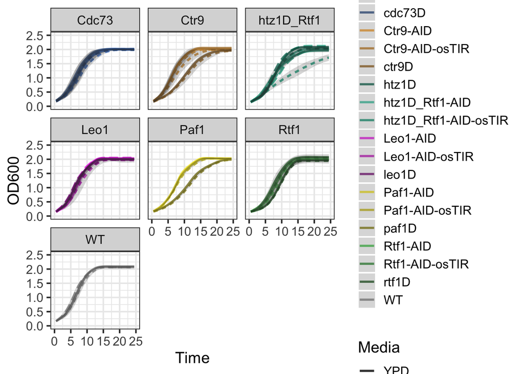

```r
  ggplot(GC_Data_Reduced[GC_Data_Reduced$Target != "Blank",], aes(x=Time, y=OD600, color = `Mutant`, group = ConditionByPlate)) +
    geom_line(aes(linetype = `Media`), alpha=0.8, size = 1 ) + theme_bw(base_size = 15) + geom_ribbon(aes(ymin=(OD600 - sdByBioRep), ymax=(OD600 + sdByBioRep), alpha = .05), linetype="blank", alpha=0.2)+
    scale_colour_manual(values = cols) + scale_fill_manual(values = cols)+  xlim(0,25) +  ylim(0,2.5) + facet_wrap(~Target, ncol = 3)
```

Now using the aggregated tech reps, I take the average curve and use the inflection package to ID the inflection point (i.e. when log growth just begins to slow). This will give me a standardized reference point to calculate slope from. I cut the data to ensure I give the culture 2 hr to get out of log phase before a viable inflection point can be found

```r
# If I don't trim the data between 2-20 hr, I find I sometimes get early inflection points that are just fluctuations in the measurements
    inflectionPointMatrix <- as.data.frame(GC_Data_Long[GC_Data_Long$Mutant != "Blank" & GC_Data_Long$Time > 1.9 & GC_Data_Long$Time < 20, ] %>%
                                             group_by(BioRep_Index, Media) %>%
                                             do({
                                               y = as.vector(.$OD600)
                                               x = as.vector(.$Time)
                                               cc = check_curve(x,y)
                                               ip = (bese(x,y,cc$index))
                                               data.frame(curveType = cc$ctype, inflectionPoint = ip$iplast)
                                             }))
    # if there are datasets with no detectable IP, they will be stored in NoIPDatasets
    NoIPDatasets <- inflectionPointMatrix[rowSums(is.na(inflectionPointMatrix)) != 0,]

    # pulls out only datasets with IP so as not to disrupt downstream analysis
    inflectionPointMatrix <- inflectionPointMatrix[rowSums(is.na(inflectionPointMatrix)) == 0,]

  # prints out if there are some datasets without an Inflection point
  NoIPDatasets
```

```
##                      BioRep_Index   Media curveType inflectionPoint
## 74 htz1D_Rtf1-AID-osTIR_YPD_Aux_4 YPD_Aux    convex             NaN
```

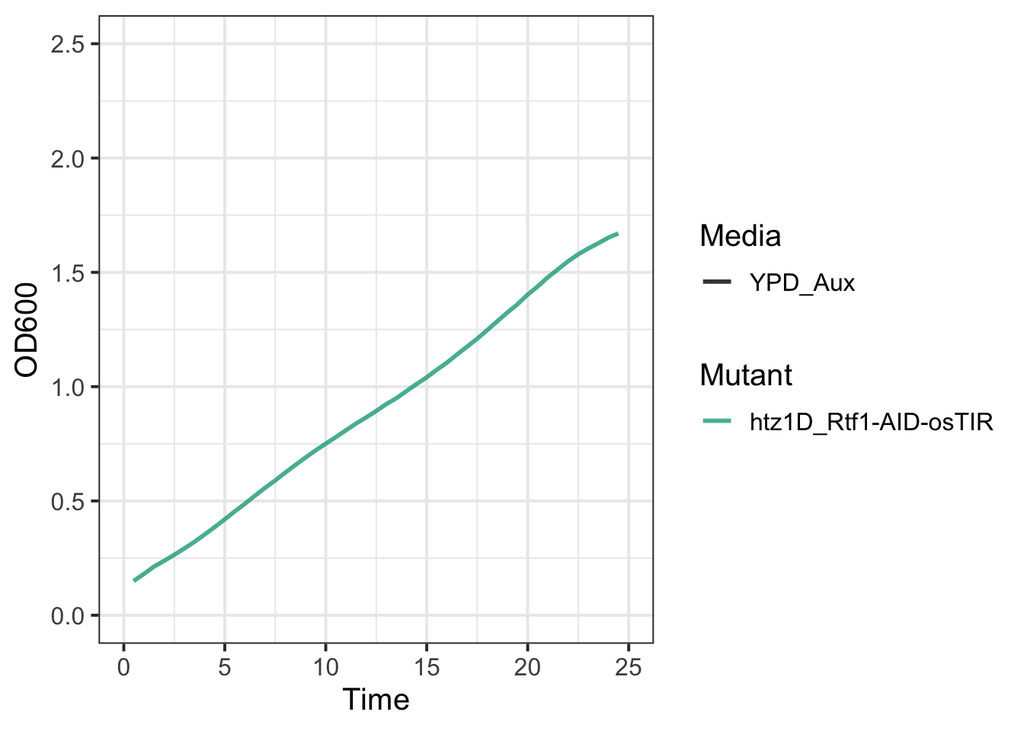

```r
  # plots IP-less curves for visual inspection
  ggplot(GC_Data_Long[GC_Data_Long$BioRep_Index == NoIPDatasets$BioRep_Index,], aes(x=Time, y=OD600, color = `Mutant`, group = `BioRep_Index`)) +
    geom_line(aes(linetype = `Media`), alpha=0.8, size = 1 ) + theme_bw(base_size = 15) +
    scale_colour_manual(values = cols) +  xlim(0,25) +  ylim(0,2.5)
```

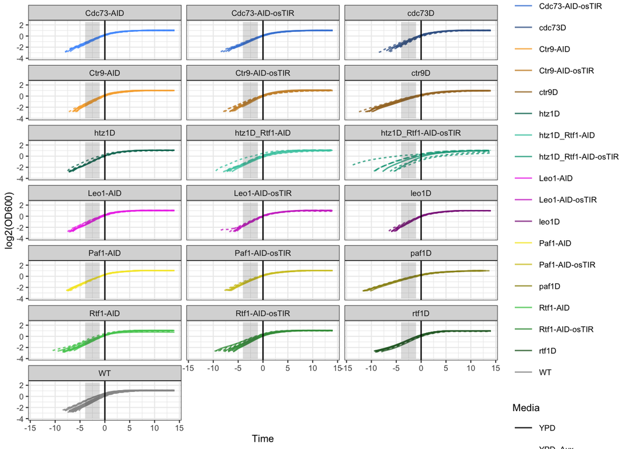

```r
 # transforming Datasets to align with IP at T = 14 this time is fairly arbitrary, but gives some time leading up and after the IP
  GC_Data_Long_IP <- merge(GC_Data_Long, inflectionPointMatrix[,c(1,4)], by.x = 'BioRep_Index', by.y = 'BioRep_Index')
  GC_Data_Long_IP$Time = (GC_Data_Long_IP$Time - GC_Data_Long_IP$inflectionPoint)
  GC_Data_Long_IP$BioRep <- str_sub(GC_Data_Long_IP$BioRep_Index, -1)

 # plotting the curves shifted to align with midpoints and with a grey rectangle highlighting the line segment used for extracting slopes

  IPShifted_plot_log2 <- ggplot(GC_Data_Long_IP[GC_Data_Long_IP$Target != "Blank",], aes(x=Time, y=log2(OD600), color = `Mutant`, group = `BioRep_Index`)) +
    geom_line(aes(linetype = `Media`), alpha=0.8, size = .5 ) + theme_bw(base_size = 8) +
    scale_colour_manual(values = cols) +  xlim(-14,14) +  ylim(-4,2.5) + facet_wrap(~Mutant, ncol = 3) + geom_vline(xintercept = 0 ) +
    annotate("rect", xmin = -4, xmax = -1, ymin = -4, ymax = 2.5,
             alpha = .2)
  IPShifted_plot_log2
```

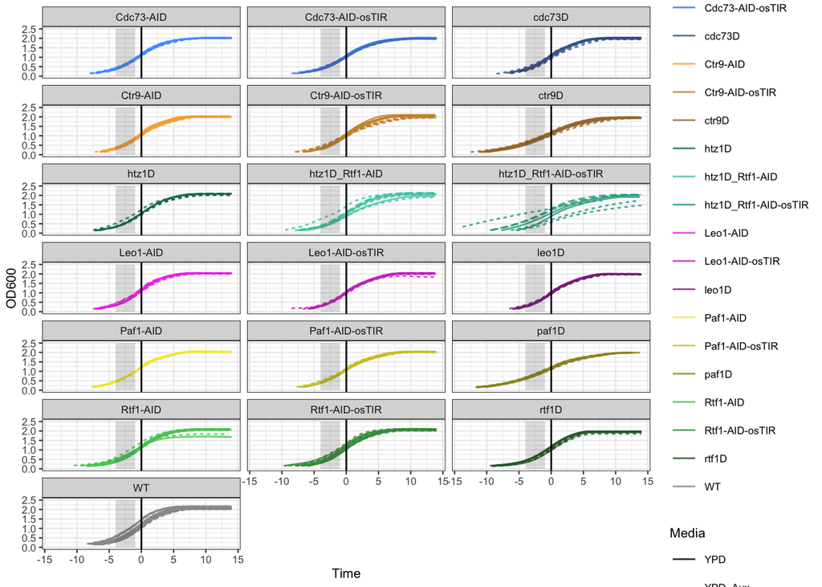

```r
  ggsave(width = 10, height = 20, "../res/IPShifted_plot_log2.pdf", IPShifted_plot_log2)
  IPShifted_plot <- ggplot(GC_Data_Long_IP[GC_Data_Long_IP$Target != "Blank",], aes(x=Time, y=OD600, color = `Mutant`, group = `BioRep_Index`)) +
    geom_line(aes(linetype = `Media`), alpha=0.8, size = .5 ) + theme_bw(base_size = 8) +
    scale_colour_manual(values = cols) +  xlim(-14,14) +  ylim(0,2.5) + facet_wrap(~Mutant, ncol = 3) + geom_vline(xintercept = 0 ) +
    annotate("rect", xmin = -4, xmax = -1, ymin = 0, ymax = 2.5,
             alpha = .2)
  IPShifted_plot
```

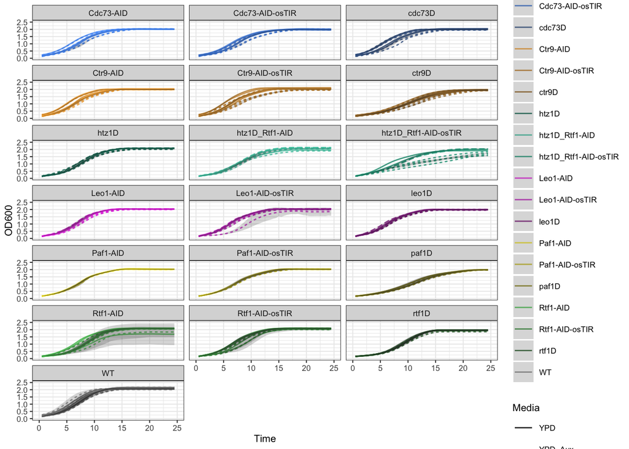

```r
  ggsave(width = 10, height = 20, "../res/IPShifted_plot.pdf", IPShifted_plot)
  # The lines below to check to see how your cut curves look
  # full traces of untransformed data
  allData_plot <- ggplot(GC_Data_Long[GC_Data_Long$Target != "Blank",], aes(x=Time, y=OD600, color = `Mutant`, group = `BioRep_Index`)) +
    geom_line(aes(linetype = `Media`), alpha=0.8, size = .5 ) + theme_bw(base_size = 8) + geom_ribbon(aes(ymin=(OD600 - sdByTechRep), ymax=(OD600 + sdByTechRep), alpha = .2), linetype="blank", alpha=0.2)+
    scale_colour_manual(values = cols) +  xlim(0,25) +  ylim(0,2.5) + facet_wrap(~Mutant, ncol = 3)
  allData_plot
```

```r
  ggsave(width = 10, height = 20, "../res/allData_plot.pdf", allData_plot)
```

```r
  # full traces of log2 transformed data
  # allData_plot_log2 <- ggplot(GC_Data_Long[GC_Data_Long$Target != "Blank",], aes(x=Time, y=log2(OD600), color = `Mutant`, group = `BioRep_Index`)) +
  #   geom_line(aes(linetype = `Media`), alpha=0.8, size = .5 ) + theme_bw(base_size = 8) +
  #   scale_colour_manual(values = cols) +  xlim(0,25) +  ylim(-2.5,2) + facet_wrap(~Mutant, ncol = 3)
  # allData_plot_log2
  # ggsave(width = 10, height = 20, "../res/allData_plot_log2.pdf", allData_plot_log2)
  #
  # allData_Reduced_plot <-  ggplot(GC_Data_Reduced[GC_Data_Reduced$Target != "Blank",], aes(x=Time, y=OD600, color = `Mutant`, group = ConditionByPlate)) +
  #   geom_line(aes(linetype = `Media`), alpha=0.8, size = 1 ) +
  #   theme_bw(base_size = 15) +
  #   geom_ribbon(aes(ymin=(OD600 - sdByBioRep),
  #                   ymax=(OD600 + sdByBioRep),
  #                   alpha = .05), linetype="F1",
  #               alpha=0.2, size = .3) +
  #   scale_colour_manual(values = cols) + scale_fill_manual(values = cols)+  xlim(0,25) +  ylim(0,2.5) + facet_wrap(~Mutant, ncol = 3)
  # allData_Reduced_plot
  # ggsave(width = 10, height = 20, "../res/allData_Reduced_plot.pdf", allData_Reduced_plot)
  #
  # # cut traces from untransformed data
  # cutTrace_plot <- ggplot(Data_subset, aes(x=Time, y=OD600, color = `Mutant`, group = `BioRep_Index`)) +
  #   geom_line(aes(linetype = `Media`), alpha=0.8, size = 1 ) + theme_bw(base_size = 15) +
  #   scale_colour_manual(values = cols)  +  xlim(0,25) +  ylim(0,2.5) + facet_wrap(~Mutant, ncol = 3)
  # cutTrace_plot
  # ggsave(width = 10, height = 20, "../res/cutTrace_plot.pdf", cutTrace_plot)
  #
  # # cut traces from log2 transformed data
  # cutTrace_plot_log2 <- ggplot(Data_subset, aes(x=Time, y=log2(OD600), color = `Mutant`, group = `BioRep_Index`)) +
  #   geom_line(aes(linetype = `Media`), alpha=0.8, size = 1 ) + theme_bw(base_size = 15) +
  #   scale_colour_manual(values = cols)  +  xlim(0,25) +  ylim(-2.5,2.5) + facet_wrap(~Mutant, ncol = 3)
  # cutTrace_plot_log2
  # ggsave(width = 10, height = 20, "../res/cutTrace_plot_log2.pdf", cutTrace_plot_log2)
  #
  # # making plate-specific plots to view tech rep data
  # for (i in unique(GC_Data_Longer$Plate_Num)) {
  #   Plot_path <-  paste("../res/DataByPlate/PlatePlot_", i, ".pdf", sep = "")
  #   print(Plot_path)
  #   tempPlot <-  ggplot(GC_Data_Longer[GC_Data_Longer$Plate_Num == as.character(i) ,], aes(x=Time, y=OD600, color = as.factor(`BioRep`), group = `Observation_Index`)) +
  #     geom_line(aes(linetype = `Media`), alpha=0.8, size = 1) + theme_bw(base_size = 16) +
  #     ggtitle(paste0("Data from Plate ", i)) +
  #     xlim(0,25) +  ylim(0,2.5) + facet_wrap(~Mutant)
  #   Plot_path
  #   ggsave(width = 10, height = 8, Plot_path, tempPlot)
  # }
  #
  # making plots by target
  for (i in unique(GC_Data_Long$Target)) {
    Plot_path <-  paste("../res/DataByTargetGene/TargetPlot_", i, ".pdf", sep = "")
    print(Plot_path)
    tempPlot <- ggplot(GC_Data_Long[GC_Data_Long$Target == i,], aes(x=Time, y=OD600, color = Mutant, group = `BioRep_Index`)) +
      geom_line(aes(linetype = `Media`), alpha=0.8, size = 1) + theme_bw(base_size = 16) +
      ggtitle(paste0(i, "Data")) + scale_color_manual(values = cols) +
      xlim(0,25) +  ylim(0,2.5) + facet_wrap(~Mutant)
    ggsave(width =20, height = 5, Plot_path, tempPlot)
  }
```

```
## [1] "../res/DataByTargetGene/TargetPlot_Blank.pdf"
```

```
## [1] "../res/DataByTargetGene/TargetPlot_Cdc73.pdf"
```

```
## [1] "../res/DataByTargetGene/TargetPlot_Ctr9.pdf"
```

```
## [1] "../res/DataByTargetGene/TargetPlot_htz1D_Rtf1.pdf"
```

```
## [1] "../res/DataByTargetGene/TargetPlot_Leo1.pdf"
```

```
## [1] "../res/DataByTargetGene/TargetPlot_Paf1.pdf"
```

```
## [1] "../res/DataByTargetGene/TargetPlot_Rtf1.pdf"
```

```
## [1] "../res/DataByTargetGene/TargetPlot_WT.pdf"
```

```r
Data_subset <- GC_Data_Long_IP[(GC_Data_Long_IP$Time > (GC_Data_Long_IP$inflectionPoint - 3.48) & GC_Data_Long_IP$Time < (GC_Data_Long_IP$inflectionPoint - 0.48)),]
  slopes <- as.data.frame(Data_subset %>%
                            group_by(BioRep_Index, Mutant, Media, Target) %>%
                            do({
                              mod = lm(log2(OD600) ~ Time, data = .)
                              data.frame(Intercept = coef(mod)[1],
                                         Slope = coef(mod)[2])
                            }))
  slopes$DT <- (1/slopes$Slope)
```

```r
DTMatrix <- as.data.frame(cbind(Mutant = slopes$Mutant,
                                  BioRep_Index = str_remove( str_remove(str_remove(slopes$BioRep_Index, "_YPD"), "_Aux"),
                                                             "_Veh"),
                                  Media = slopes$Media,
                                  Target = slopes$Target,
                                  DT = slopes$DT))

DTMatrix$BioRep <- str_sub(DTMatrix$BioRep_Index, -1)
DTMatrix$DT <- as.numeric(DTMatrix$DT)

DTMatrix <- DTMatrix[order(DTMatrix$BioRep_Index),]
attach(DTMatrix)
DTMatrix
```

```
##                   Mutant           BioRep_Index   Media     Target           DT
## 1              Cdc73-AID            Cdc73-AID_1     YPD      Cdc73    12.242877
## 5              Cdc73-AID            Cdc73-AID_1 YPD_Aux      Cdc73    11.727825
## 2              Cdc73-AID            Cdc73-AID_2     YPD      Cdc73    29.337735
## 6              Cdc73-AID            Cdc73-AID_2 YPD_Aux      Cdc73    29.713637
## 3              Cdc73-AID            Cdc73-AID_3     YPD      Cdc73    32.313795
## 7              Cdc73-AID            Cdc73-AID_3 YPD_Aux      Cdc73    25.402361
## 4              Cdc73-AID            Cdc73-AID_4     YPD      Cdc73    22.086385
## 8              Cdc73-AID            Cdc73-AID_4 YPD_Aux      Cdc73    26.393158
## 9        Cdc73-AID-osTIR      Cdc73-AID-osTIR_1     YPD      Cdc73    14.459971
## 13       Cdc73-AID-osTIR      Cdc73-AID-osTIR_1 YPD_Aux      Cdc73    12.110067
## 10       Cdc73-AID-osTIR      Cdc73-AID-osTIR_2     YPD      Cdc73    13.739416
## 14       Cdc73-AID-osTIR      Cdc73-AID-osTIR_2 YPD_Aux      Cdc73    15.804587
## 11       Cdc73-AID-osTIR      Cdc73-AID-osTIR_3     YPD      Cdc73    28.082045
## 15       Cdc73-AID-osTIR      Cdc73-AID-osTIR_3 YPD_Aux      Cdc73    30.046660
```

[output cut: 375 more lines]

```r
DTMatrix_avg <- DTMatrix %>%
  group_by(Mutant, Media, Target) %>%
  summarise(
    meanDT = mean(DT),
    sdDT = sd(DT)
  )
```

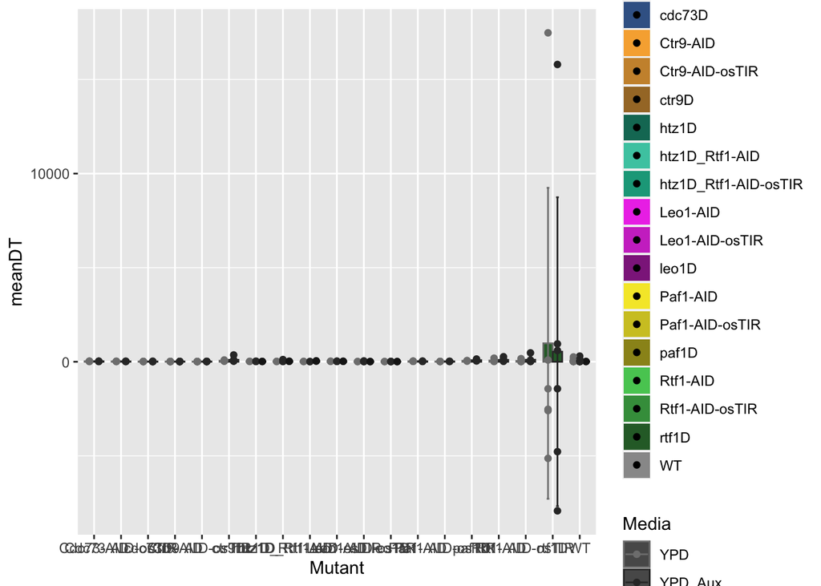

```r
DT_plot <- ggplot(DTMatrix_avg, aes(x=Mutant, y=meanDT, group=Media, fill = Mutant, color = Media)) +
  geom_col( width=0.7, position=position_dodge(), alpha = 1) +
  geom_errorbar(aes(ymin=meanDT-sdDT, ymax=meanDT+sdDT), width=.2,
                position=position_dodge(.7)) +
  scale_fill_manual(values = cols) +
  geom_point(data = DTMatrix, aes(x=Mutant, y=DT, group=Media, fill = Mutant, color = Media),
             position=position_dodge(.7) ) +
  scale_color_manual(values = c("grey50", "grey20", "grey10"))
DT_plot
```

```r
ggsave(width = 25, height = 6, "../res/DT_plot.pdf", DT_plot)
# looking at data in a bio-rep paired manner
# DTDiffMatrix <- cbind(DTMatrix[(Media == "YPD" | Media == "YPD_Veh"),1:3])
# diff <- DTMatrix[(Media == "YPD" | Media == "YPD_Veh"),]$DT - DTMatrix[Media == "YPD_Aux",]$DT
# DTDiffMatrix <- cbind(DTDiffMatrix, diff, YPD_DT = DTMatrix[Media == "YPD",]$DT)
# # DTDiffMatrix$percentdiff <- DTDiffMatrix$diff/DTDiffMatrix
# DTDiffMatrix_avg <- DTDiffMatrix %>%
#   group_by(Mutant) %>%
#   summarise(
#     meanDTDiff = mean(diff),
#     sdDT = sd(diff)
#   )
#
# DT_diff_plot <- ggplot(DTDiffMatrix_avg, aes(x=Mutant, y=meanDTDiff, group=Mutant, fill = Mutant, color = Mutant)) +
#   geom_col( width=.9, position="dodge", alpha = 1, color = "black") +
#   geom_errorbar(aes(ymin=meanDTDiff-sdDT, ymax=meanDTDiff+sdDT), width=.2,
#                 position=position_dodge(.7), color = "black") +
#   scale_fill_manual(values = cols) + theme_bw(base_size = 10) +
#   geom_point(data = DTDiffMatrix, aes(x=Mutant, y=diff),
#              position=position_dodge(.7), color = "Black")
# ggsave(width = 20, height = 6, "../res/DT_diff_plot.pdf", DT_diff_plot)
#
#
# ggplot(DTDiffMatrix, aes(x=Mutant, y=diff, group=Mutant, color = Mutant)) +
#   geom_point(position=position_dodge(.7) ) +
#   scale_color_manual(values = cols)
```